# C-POD data workshop: Mapping

## 2. Autocorrelation

R provides a very easy function to investigate the autocorrelation in your data: acf.

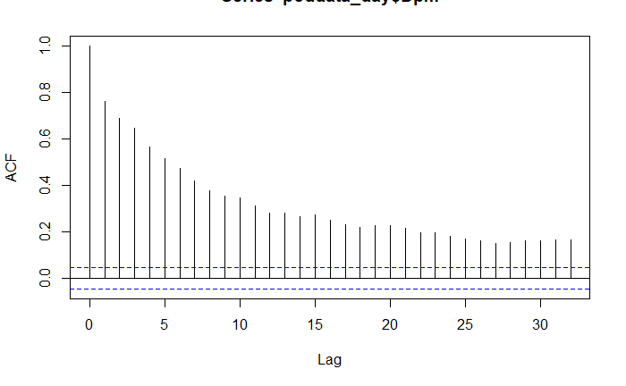

```r
acf(poddata_day$Dpm)
```

Again, we are interested in the autocorrelation of each Zone seperately.

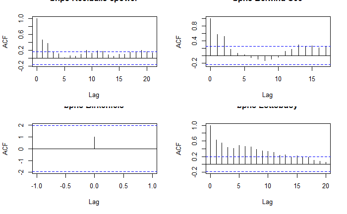

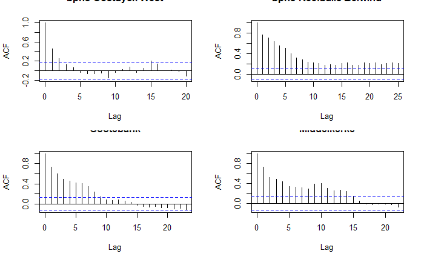

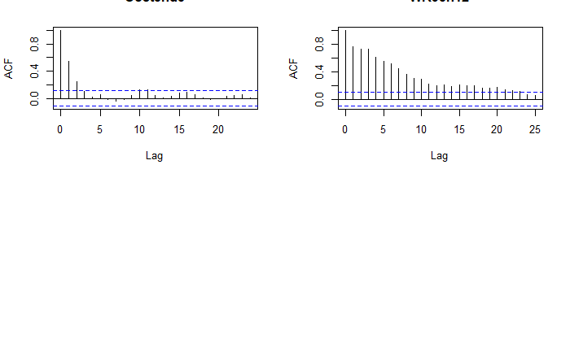

```r
par(mfrow=c(2,2)) # see four plots at a time
lapply(unique(poddata_day$Zone), function(x) {
  data <- acf(poddata_day[poddata_day$Zone == x,]$Dpm, plot = F)
  plot(data, main = x)
})
```

We can also take these values and combine them in one plot.

```r
lacf <- lapply(unique(poddata_day$Zone), function(x){
  o <- filter(poddata_day, Zone == x)
  oa <- acf(o$Dpm)
  dfo <- data.frame(acf = oa$acf[,,1], lag = oa$lag[,,1], Zone = x)
})
library(plyr) # Now we use the package plyr to make a dataframe out of our list
dacf <- ldply(lacf, rbind)
```

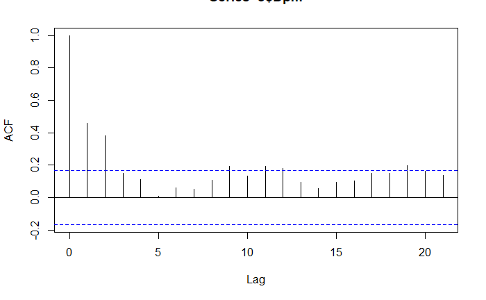

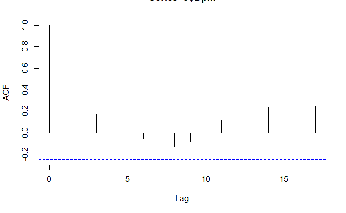

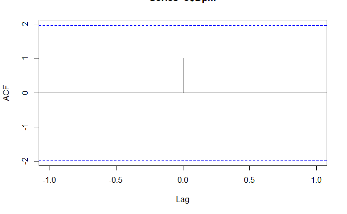

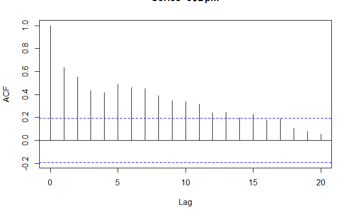

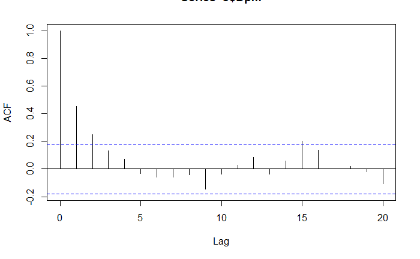

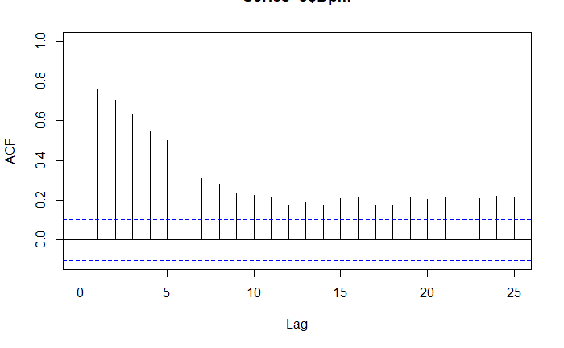

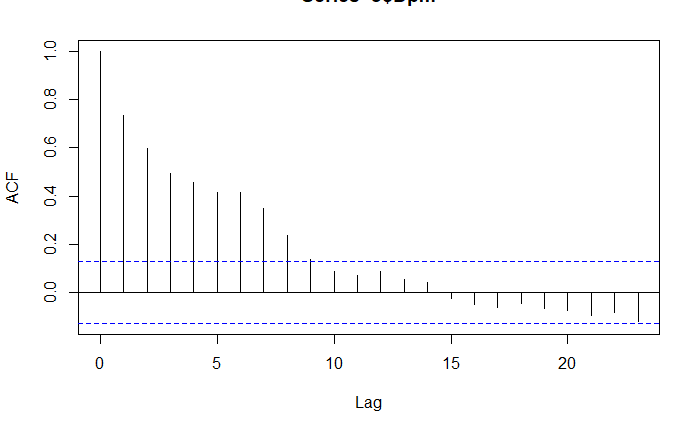

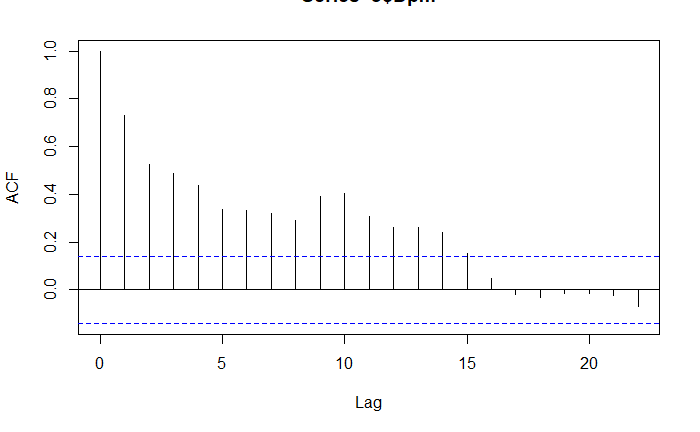

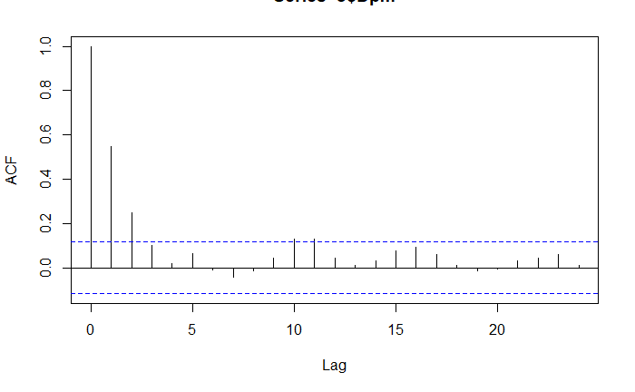

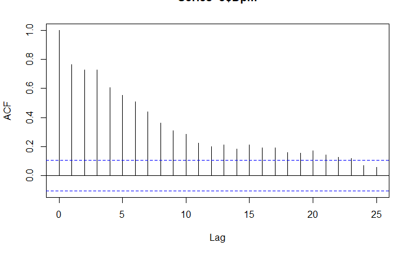

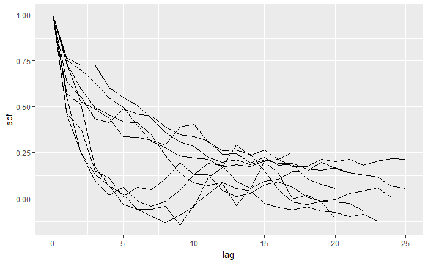

```r
lacf <- lapply(unique(poddata_day$Zone), function(x){
  o <- filter(poddata_day, Zone == x)
  oa <- acf(o$Dpm)
  dfo <- data.frame(acf = oa$acf[,,1], lag = oa$lag[,,1], Zone = x)
})

library(plyr) # Now we use the package plyr to make a dataframe out of our list
dacf <- ldply(lacf, rbind)
ggplot(dacf) + geom_path(aes(x=lag, y=acf, group=Zone))
```

## 3. Smoothing

The goal of smoothing is generally to aid visual interpretation of a time series. Let’s try on two subsets of our data.

```r
test1 <- filter(poddata_day, Deployment_fk == 2578)
test2 <- filter(poddata_day, Deployment_fk == 2585)
```

Applying geom_smooth() plots a loess smoother (weighted regression) on the series.

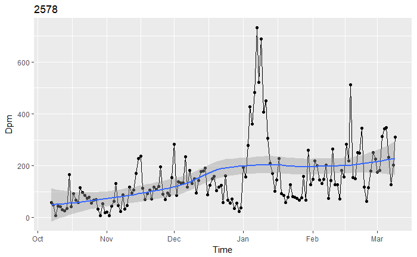

```r
ggplot(data = test1, aes(x = Time, y = Dpm)) +
  geom_point() + geom_line() + geom_smooth() + ggtitle(2578)
```

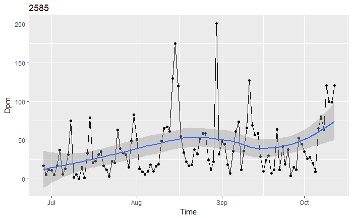

```r
ggplot(data = test2, aes(x = Time, y = Dpm)) +
  geom_point() + geom_line() + geom_smooth() + ggtitle(2585)
```

Another way to smooth data, is to calculate a moving average.

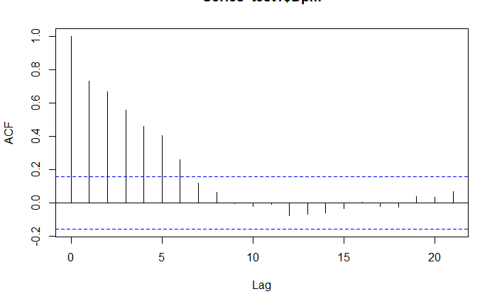

```r
acf(test1$Dpm) # First, we check the autocorrelation to choose our window size.
```

```r
movavg # movavg is a list
```

```
 Call:
 decaverage(x = test1$Dpm, order = 3)

Components
[1] "filtered"  "residuals"
```

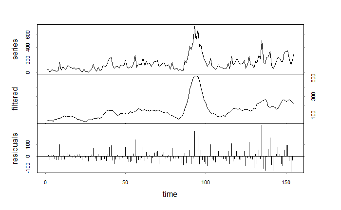

```r
plot(movavg)
```

Now in **ggplot**:

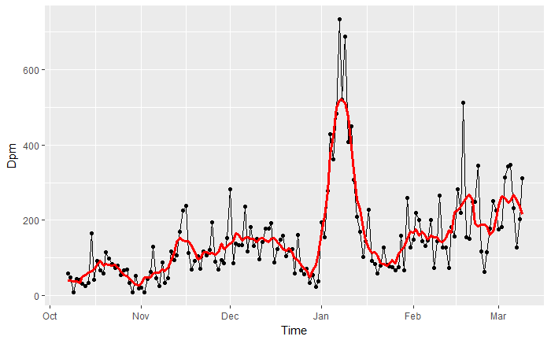

```r
ggplot(test1, aes(x = Time, y = Dpm)) + geom_point() + geom_line() +
  geom_path(aes(y = decavg), size= 1.2, colour = "red")
```

[figure not shown]

```r
ggplot(test1, aes(x = Time, y = Dpm)) + geom_point() + geom_line() +
  geom_path(aes(y = decavg), size= 1.2, colour = "red")
```

Now, we can do the same for the other subset.

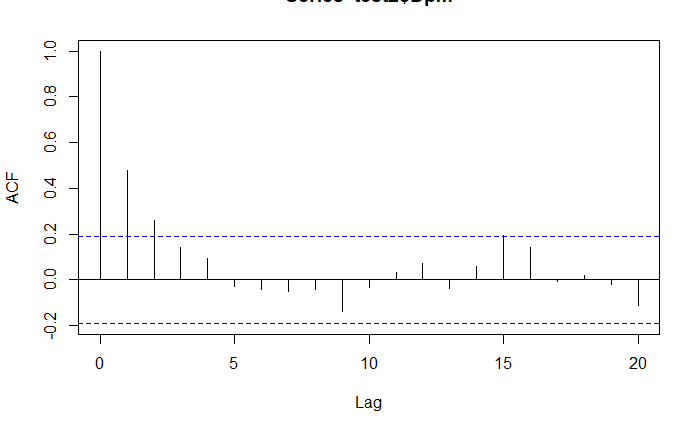

```r
acf(test2$Dpm)
```

```r
movavg <- decaverage(test2$Dpm, order = 1, times = 5)
test2$decavg <- data.frame(movavg$series)$filtered
```

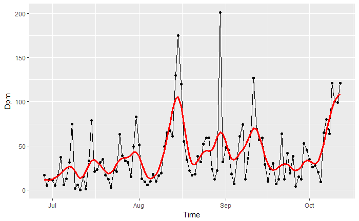

```r
ggplot(test2, aes(x = Time, y = Dpm)) + geom_point() + geom_line() +
  geom_path(aes(y = decavg), size= 1.2, colour = "red")
```

Discussion: which smoothing technique is preferred? Is smoothing necessary?